# ROCnReg: An R Package for Receiver Operating Characteristic Curve Inference With and Without Covariates

This paper introduces the package *ROCnReg* that allows estimating the pooled ROC curve, the covariate-specific ROC curve, and the covariate-adjusted ROC curve by different methods, both from (semi) parametric and nonparametric perspectives and within Bayesian and frequentist paradigms. From the estimated ROC curve (pooled, covariate-specific, or covariate-adjusted), several summary measures of discriminatory accuracy, such as the (partial) area under the ROC curve and the Youden index, can be obtained. The package also provides functions to obtain ROC-based optimal threshold values using several criteria, namely, the Youden index criterion and the criterion that sets a target value for the false positive fraction. For the Bayesian methods, we provide tools for assessing model fit via posterior predictive checks, while the model choice can be carried out via several information criteria. Numerical and graphical outputs are provided for all methods. This is the only package implementing Bayesian procedures for ROC curves.

María Xosé Rodríguez-Álvarez (BCAM - Basque Center for Applied Mathematics and IKERBASQUE, Basque Foundation for Science) , Vanda Inácio (School of Mathematics)  
2021-07-15

## 1 Introduction

The receiver operating characteristic (ROC) curve (Metz 1978) is, unarguably, the most popular tool used for evaluating the discriminatory ability of continuous-outcome diagnostic tests. The ROC curve displays the false positive fraction (FPF) against the true positive fraction (TPF) for all possible threshold values that can be used to dichotomize the test result. The ROC curve thus provides a global description of the trade-off between the FPF and the TPF of the test as the threshold changes. Plenty of parametric and semi/nonparametric methods are available for estimating the ROC curve, either from frequentist or Bayesian viewpoints, and we refer the interested reader to Pepe (1998 5), Zhou et al. (2011 4), (Inácio et al. 2020), and references therein.

It is known that in many situations, the outcome of a test and, possibly, its discriminatory capacity can be affected by covariates. Two different ROC-based measures that incorporate covariate information have been proposed: the covariate-specific or conditional ROC curve (see, e.g., Pepe 2003 6) and the covariate-adjusted ROC curve (Janes and Pepe 2009). The formal definition of both curves is given in Section 2. Succinctly, a covariate-specific ROC curve is an ROC curve that conditions on a specific covariate value, thus describing the accuracy of the test in the ‘subpopulation’ defined by that covariate value. On the other hand, the covariate-adjusted ROC curve is a weighted average of covariate-specific ROC curves. Regarding estimation, since the seminal paper of (Pepe 1998), a plethora of methods have been proposed in the literature for the estimation of the covariate-specific ROC curve and associated summary measures. Without being exhaustive, we mention the work of (Faraggi 2003), (Rodríguez-Álvarez et al. 2011b,a), (Inácio de Carvalho et al. 2013), and (Inácio de Carvalho et al. 2017). A detailed review can be found in (Rodríguez-Álvarez et al. 2011c), (Pardo-Fernández et al. 2014), and (Inácio et al. 2020). With respect to the covariate-adjusted ROC curve, estimation has been discussed in (Janes and Pepe 2009), (Rodríguez-Álvarez et al. 2011b), (Guan et al. 2012), and (Inácio de Carvalho and Rodríguez-Álvarez 2018).

A few R packages for ROC curve analysis are available on the Comprehensive R Archive Network and, as far as we are aware, all of them implementing frequentist approaches. The package [*sROC*](https://CRAN.R-project.org/package=sROC) (Wang 2012) contains functions to perform nonparametric, kernel-based, estimation of ROC curves. [*pROC*](https://CRAN.R-project.org/package=pROC) (Robin et al. 2011) offers a set of tools to visualize, smooth, and compare ROC curves, and [*nsROC*](https://CRAN.R-project.org/package=nsROC) (Pérez Fernández et al. 2018) also allows estimating ROC curves, building confidence bands as well as comparing several curves both for dependent and independent data (i.e., data arising from paired and unpaired study designs, respectively). However, covariate information cannot be explicitly taken into account in any of these packages. The packages *ROCRegression* (available at https://bitbucket.org/mxrodriguez/rocregression) and [*npROCRegression*](https://CRAN.R-project.org/package=npROCRegression) (Rodriguez-Alvarez and Roca-Pardinas 2017) provide routines to estimate semiparametrically and nonparametrically, under a frequentist framework, the covariate-specific ROC curve. We also mention [*OptimalCutpoints*](https://CRAN.R-project.org/package=OptimalCutpoints) (López-Ratón et al. 2014) and [*ThresholdROC*](https://CRAN.R-project.org/package=ThresholdROC) (Perez Jaume et al. 2017) that provide a collection of functions for point and interval estimation of optimal thresholds for continuous diagnostic tests. To the best of our knowledge, there is no statistical software package implementing Bayesian inference for ROC curves and associated summary indices and optimal thresholds.

To close this gap, in this paper we introduce the [*ROCnReg*](https://CRAN.R-project.org/package=ROCnReg) package that allows conducting Bayesian inference for the (pooled or marginal) ROC curve, the covariate-specific ROC curve, and the covariate-adjusted ROC curve. For the sake of generality, frequentist approaches are also implemented. Specifically, in what concerns estimation of the pooled ROC curve, *ROCnReg* implements the frequentist empirical estimator described in (Hsieh and Turnbull 1996), the kernel-based approach proposed by (Zou et al. 1997), the Bayesian Bootstrap method of (Gu et al. 2008), and the Bayesian nonparametric method based on a Dirichlet process mixture of normal distributions model proposed by (Erkanli et al. 2006). Regarding the covariate-specific ROC curve, *ROCnReg* implements the frequentist normal method of (Faraggi 2003) and its semiparametric counterpart as described in (Pepe 1998), the kernel-based approach of (Rodríguez-Álvarez et al. 2011b), and the Bayesian nonparametric model based on a single-weights dependent Dirichlet process mixture of normal distributions proposed by (Inácio de Carvalho et al. 2013). As for the covariate-adjusted ROC curve, the *ROCnReg* package allows estimation using the frequentist semiparametric approach of (Janes and Pepe 2009), the frequentist nonparametric method discussed in (Rodríguez-Álvarez et al. 2011b), and the recently proposed Bayesian nonparametric estimator of (Inácio de Carvalho and Rodríguez-Álvarez 2018). Table 1 shows a summary of all methods implemented in the package. In addition, *ROCnReg* also provides functions to obtain ROC-based optimal thresholds to perform the classification/diagnosis of individuals as, say, diseased or nondiseased, using two different criteria, namely, the Youden index and the criterion that sets a target value for the false positive fraction. These are implemented for both the ROC curve, the covariate-specific, and the covariate-adjusted ROC curve.

Table 1: Overview of ROC estimation methods included in the *ROCnReg* package.

| Method | Description |
| --- | --- |
| Pooled ROC curve |  |
| emp | (Frequentist) empirical estimator (Hsieh and Turnbull 1996). |
| kernel | (Frequentist) kernel-based approach (Zou et al. 1997). |
| BB | Bayesian bootstrap method (Gu et al. 2008). |
| dpm | Nonparametric Bayesian approach based on a Dirichlet process mixture of normal distributions (Erkanli et al. 2006). |
| Covariate-specific ROC curve |  |
| sp | (Frequentist) parametric and semiparametric induced ROC regression approach (Pepe 1998; Faraggi 2003) |
| kernel | Nonparametric (kernel-based) induced ROC regression approach (Rodríguez-Álvarez et al. 2011b). |
| bnp | Nonparametric Bayesian model based on a single-weights dependent Dirichlet process mixture of normal distributions (Inácio de Carvalho et al. 2013). |
| Covariate-adjusted ROC curve |  |
| sp | (Frequentist) semiparametric method (Janes and Pepe 2009). |
| kernel | Nonparametric (kernel-based) induced ROC regression approach (Rodríguez-Álvarez et al. 2011b). |
| bnp | Nonparametric Bayesian model based on a single-weights dependent Dirichlet process mixture of normal distributions and the Bayesian bootstrap (Inácio de Carvalho and Rodríguez-Álvarez 2018). |

The remainder of the paper is organized as follows. In Section 2, we formally introduce the (pooled or marginal) ROC curve, the covariate-specific ROC curve, and the covariate-adjusted ROC curve. The description of the Bayesian estimation methods implemented in the *ROCnReg* package is given in Section 3. In Section 4, the usage of the main functions and capabilities of *ROCnReg* are described and illustrated using a synthetic dataset mimicking endocrine data. The paper concludes with a discussion in Section 5.

## 2 Notation and definitions

This section sets out the formal definition of the pooled or marginal ROC curve, the covariate-specific ROC curve, and the covariate-adjusted ROC curve. It also describes the most commonly used summary measures of discriminatory accuracy, namely, the area under the ROC curve, the partial area under the ROC curve, and the Youden Index. For conciseness, we intentionally avoid giving too many details and refer the interested reader to (Pepe 2003) (and references therein) for an extensive account of many aspects of ROC curves with and without covariates.

In what follows, we denote as $Y$ the outcome of the diagnostic test and as $D$ the binary variable indicating the presence ($D = 1$) or absence ($D = 0$) of disease. We also assume that along with $Y$ and the true disease status $D$, a covariate vector $\mathbf{X}$ is also available and that it may encompass both continuous and categorical covariates. For ease of notation, the covariate vector $\mathbf{X}$ is assumed to be the same in both the diseased ($D = 1$) and nondiseased ($D = 0$) populations, although this is not always necessarily the case in practice (e.g., disease stage is, obviously, a disease-specific covariate). By a slight abuse of notation, we use the subscripts $D$ and $\bar{D}$ to denote (random) quantities conditional on, respectively, $D = 1$ and $D = 0$. For example, $Y_{D}$ and $Y_{\bar{D}}$ denote the test outcomes in the diseased and nondiseased populations, respectively.

### 2.1 Pooled ROC curve

In the case of a continuous-outcome diagnostic test, the classification is usually made by comparing the test result $Y$ against a threshold $c$. If the outcome is equal or above the threshold, $Y \geq c$, the subject will be diagnosed as diseased. On the other hand, if the test result is below the threshold, $Y < c$, he or she will be classified as nondiseased. The ROC curve is then defined as the set of all possible pairs of false positive fractions, $\text{FPF}\left(c\right) = \Pr(Y \geq c \mid D = 0) = \Pr(Y_{\bar{D}} \geq c)$, and true positive fractions, $\text{TPF}\left(c\right) = \Pr(Y \geq c \mid D = 1) = \Pr(Y_D \geq c)$, that can be obtained by varying the threshold value $c$, i.e.,
$$\left\{\left(\text{FPF}\left(c\right), \text{TPF}\left(c\right)\right): c \in \mathbb{R} \right\}.$$
It is common to represent the ROC curve as $\left\{\left(p, \text{ROC}(p)\right): p \in [0,1] \right\}$, where
$$\label{ROC}
p=\text{FPF}(c) = 1 -F_{\bar{D}}(c),\quad \text{ROC}(p) = 1 - F_D\left\{F_{\bar{D}}^{-1}(1-p)\right\}, \tag{1}$$
with $F_{\bar{D}}\left(y\right) = \Pr(Y_{\bar{D}} \leq y)$ and $F_{D}\left(y\right) = \Pr(Y_{D} \leq y)$ denoting the cumulative distribution function (CDF) of $Y$ in the nondiseased and diseased groups, respectively. Several indices can be used as global summary measures of the accuracy of a test. The most widely used is the area under the ROC curve (AUC), defined as
$$\label{AUC1}
\text{AUC} = \int_{0}^{1}\text{ROC}\left(p\right)\text{d}p. \tag{2}$$
In addition to its geometric definition, the AUC has also a probabilistic interpretation (see, e.g., Pepe 2003 78)
$$\label{AUC2}
\text{AUC} = \Pr\left(Y_{D} \geq Y_{\bar{D}}\right), \tag{3}$$
that is, the AUC is the probability that a randomly selected diseased subject has a higher test outcome than that of a randomly selected nondiseased subject. The AUC takes values between $0.5$, in the case of an uninformative test that classifies individuals no better than chance, and $1.0$ for a perfect test. We note that an AUC below $0.5$ simply means that the classification rule should be reversed. As it is clear from its definition, the AUC integrates the ROC curve over the whole range of FPFs. However, depending on the clinical circumstances, interest might lie only on a relevant interval of FPFs or TPFs, which leads to the notion of the partial area under the ROC curve (pAUC). The pAUC over a range of FPFs $\left(0, u_1\right)$, where $u_1$ is typically low and represents the largest acceptable FPF, is defined as
$$\label{pAUC}
\text{pAUC}\left(u_1\right) = \int_{0}^{u_1}\text{ROC}\left(p\right)\text{d}p. \tag{4}$$
On the other hand, the pAUC over a range of TPFs $(v_1,1)$, where $v_1$ is typically large and represents the lowest acceptable TPF, is defined as
$$\label{pAUC_TPF}
\text{pAUC}_{\text{TPF}}\left(v_1\right) = \int_{v_1}^{1}\text{ROC}_{\text{TNF}}\left(p\right)\text{d}p, \tag{5}$$
where $\text{ROC}_{\text{TNF}}$ is a $270^\circ$ rotation of the ROC curve, which can be expressed as
$$\label{ROC_TNF}
\text{ROC}_{\text{TNF}}(p) = F_{\bar{D}}\{F_{D}^{-1}(1-p)\}. \tag{6}$$
The curve in ((6)) is referred to as the true negative fraction (TNF) ROC curve since TNF ( $= 1 - \text{FPF}$) is plotted on the $y$-axis. We shall highlight that the argument $p$ in the ROC curve stands for a false positive fraction, whereas in the $\text{ROC}_{\text{TNF}}$ curve, it stands for a true positive fraction. In Figure 1, we graphically illustrate the two partial areas.

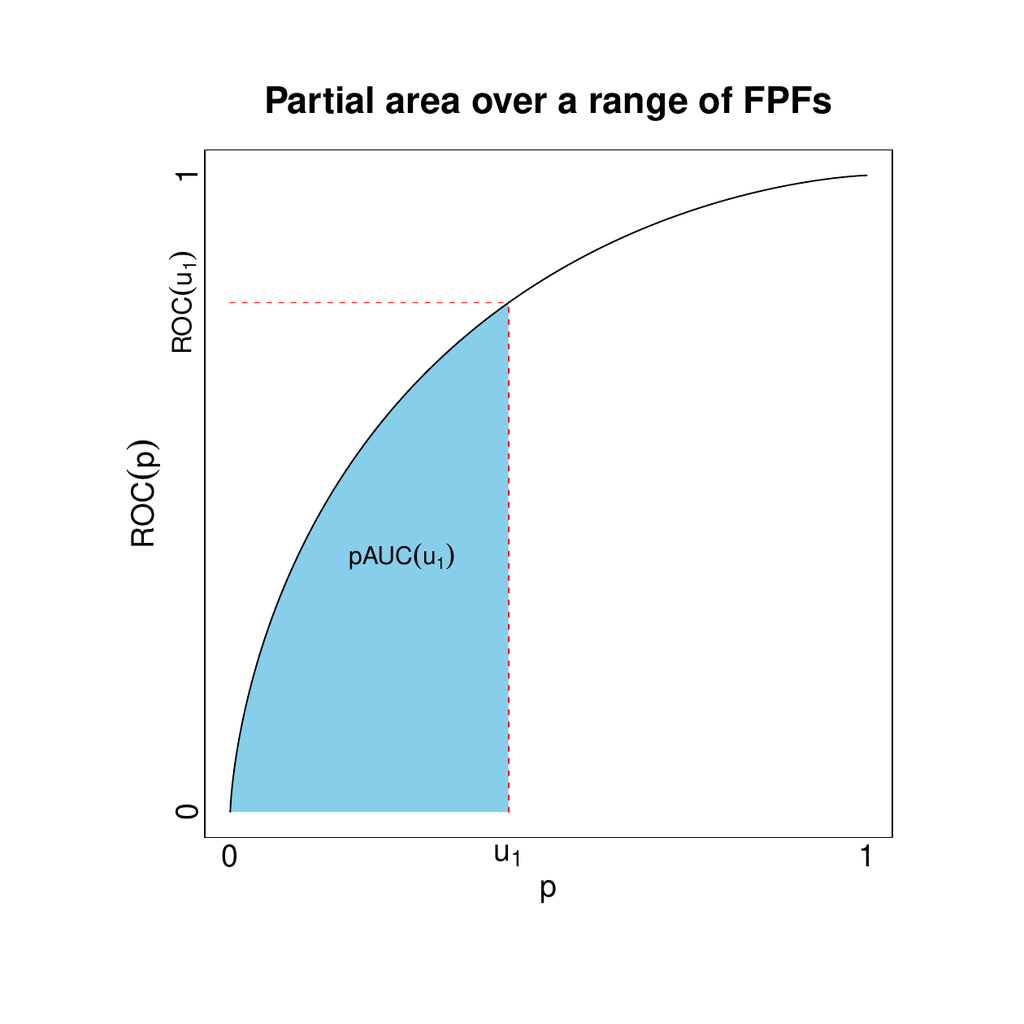

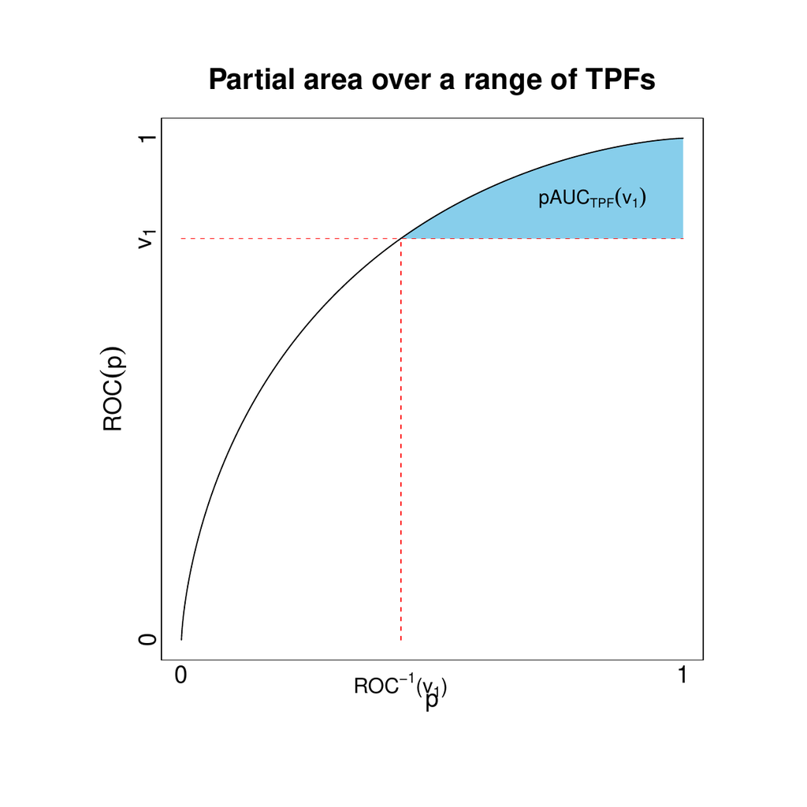

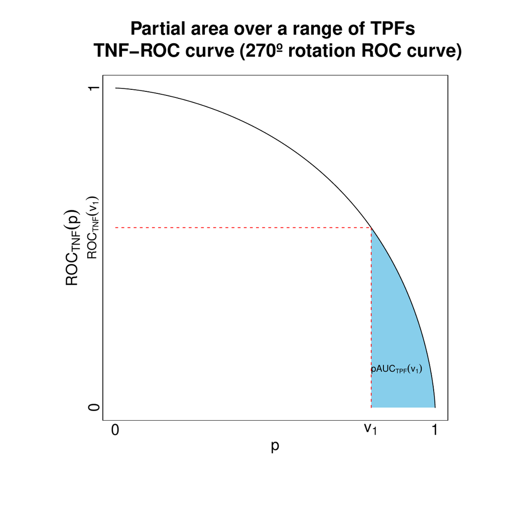

(a)

(b)

(c)

Figure 1: (a) Shaded area in blue represents the partial area under the ROC curve over the interval (0,*u*<sub>1</sub>) of FPFs. (b) Shaded area in blue represents the partial area under the ROC curve over the interval (*v*<sub>1</sub>,1) of TPFs. (c) The same as in (b) but now represented as an area under the true negative fraction ROC curve.

Another summary index of diagnostic accuracy is the Youden index (Youden 1950; Shapiro 1999)
$$\begin{aligned}
\text{YI} & = \max_{c}\left\{\text{TPF}(c)-\text{FPF}(c)\right\} \label{YI1}
\end{aligned} \tag{7}$$

$$\begin{aligned}
& = \max_{c}\left\{F_{\bar{D}}\left(c\right) - F_{D}\left(c\right)\right\} \label{YI2}
\end{aligned} \tag{8}$$

$$\begin{aligned}
& = \max_{p}\left\{\text{ROC}(p)-p\right\} \label{YI3}.
\end{aligned} \tag{9}$$
The YI ranges from $0$ to $1$, taking the value of $0$ in the case of an uninformative test and $1$ for a perfect test. As for the AUC, a YI below $0$ means that the classification rule should be reversed. The value $c^{*}$, which maximizes Equation (7) (or, equivalently, Equation (8)), is frequently used in practice to classify subjects as diseased or nondiseased. It should be noted that the Youden index is equivalent to the Kolmogorov–Smirnov measure of distance between the distributions of $Y_{D}$ and $Y_{\bar{D}}$ (Pepe 2003 80).

### 2.2 Covariate-specific ROC curve

The conditional or covariate-specific ROC curve, given a covariate value $\mathbf{x}$, is defined as
$$\label{ROCConditional}
\text{ROC}(p\mid\mathbf{x}) = 1-F_{D}\{F_{\bar{D}}^{-1}(1-p\mid\mathbf{x})\mid\mathbf{x}\}, \tag{10}$$
where $F_{\bar{D}}(y\mid\mathbf{x}) = \Pr(Y_{\bar{D}}\leq y\mid\mathbf{X}_{\bar{D}}=\mathbf{x})$ and $F_{D}(y\mid\mathbf{x}) = \Pr(Y_{D}\leq y\mid \mathbf{X}_{D}= \mathbf{x})$ are the conditional CDFs of the test in the nondiseased and diseased groups, respectively. In this case, a number of possibly different ROC curves (and therefore discriminatory accuracies) may be obtained for different values of $\mathbf{x}$. Thus, the covariate-specific ROC curve is an important tool that helps to understand and determine the optimal and suboptimal populations where to apply the tests on. That is, the covariate-specific ROC curve allows determining the populations, defined by or homogeneous with respect to $\mathbf{x}$, where the diagnostic test has a ‘good’ or ‘poor’ discriminatory capacity. Similarly to the unconditional case, the covariate-specific TNF-ROC curve is given by
$$\label{ROCConditional_TNF}
\text{ROC}_{\text{TNF}}(p\mid\mathbf{x}) = F_{\bar{D}}\{F_{D}^{-1}(1-p\mid\mathbf{x})\mid\mathbf{x}\}, \tag{11}$$
and the covariate-specific AUC, pAUC, and Youden index are
$$\begin{aligned}
\text{AUC}(\mathbf{x}) & = \int_{0}^{1}\text{ROC}(p\mid\mathbf{x})\text{d}p, \label{AUCConditional}
\end{aligned} \tag{12}$$

$$\begin{aligned}
\text{pAUC}(u_1 \mid \mathbf{x}) & = \int_{0}^{u_1}\text{ROC}(p\mid\mathbf{x})\text{d}p, \label{pAUCConditional}
\end{aligned} \tag{13}$$

$$\begin{aligned}
\text{pAUC}_{\text{TPF}}(v_1 \mid \mathbf{x}) & = \int_{v_1}^{1}\text{ROC}_{\text{TNF}}(p\mid\mathbf{x})\text{d}p, \label{pAUCConditional2}
\end{aligned} \tag{14}$$

$$\begin{aligned}
\text{YI}(\mathbf{x}) & = \max_{c} \lvert \text{TPF}(c\mid\mathbf{x}) - \text{FPF}(c \mid \mathbf{x}) \rvert \label{YIConditional1}
\end{aligned} \tag{15}$$

$$\begin{aligned}
& = \max_{c}\lvert F_{\bar{D}}(c\mid\mathbf{x}) - F_{D}(c\mid\mathbf{x}) \rvert \label{YIConditional2}
\end{aligned} \tag{16}$$

$$\begin{aligned}
& = \max_{p}\lvert \text{ROC}(p\mid\mathbf{x})- p \rvert \label{YIConditional3}.
\end{aligned} \tag{17}$$
The value $c^{*}_{\mathbf{x}}$ that achieves the maximum in ((15)) (or ((16))) is called the optimal covariate-specific YI threshold and can be used to classify a subject, with covariate value $\mathbf{x}$, as diseased or nondiseased.

### 2.3 Covariate-adjusted ROC curve

The covariate-specific ROC curve and associated AUC, pAUCs, and YI described in the previous section depict the accuracy of the test for specific covariate values. However, it would be undoubtedly useful to have a global summary measure that also takes covariate information into account. Such summary measure was developed by (Janes and Pepe 2009), who proposed the covariate-adjusted ROC (AROC) curve, defined as
$$\label{aroc1}
\text{AROC}(p)=\int \text{ROC}(p\mid\mathbf{x})\text{d}H_{D}(\mathbf{x}), \tag{18}$$
where $H_{D}(\mathbf{x}) = \Pr(\mathbf{X}_{D}\leq \mathbf{x})$ is the CDF of $\mathbf{X}_{D}$. That is, the AROC curve is a weighted average of covariate-specific ROC curves, weighted according to the distribution of the covariates in the diseased group. Equivalently, as shown by (Janes and Pepe 2009), the AROC curve can also be expressed as
$$\begin{aligned}
\label{aroc2}
\text{AROC}(p) & = \Pr\{Y_{D}>F_{\bar{D}}^{-1}(1-p\mid \mathbf{X}_{D})\} \nonumber \\
& = \Pr\{1-F_{\bar{D}}(Y_D\mid\mathbf{X}_{D})\leq p\}.
\end{aligned} \tag{19}$$
As will be seen in Section 3, Expression (19) is very convenient when it comes to estimating the AROC curve. Also, it emphasizes that the AROC curve at an FPF of $p$ is the overall TPF when the thresholds used for defining a positive test result are covariate-specific and chosen to ensure that the FPF is $p$ in each subpopulation defined by the covariate values.

In contrast to the pooled ROC curve (see Expressions (1) and (6)) and the covariate-specific ROC curve (see Expressions (10) and (11)), the AROC curve (and its $270^\circ$ rotation) cannot be expressed in terms of the (conditional) CDFs of the test in each group. This does not, however, preclude the possibility of defining AROC-based summary accuracy measures, yet more care is needed. Thus, for the AROC curve, the area under the AROC, as well as the partial areas and YI, are expressed as follows
$$\begin{aligned}
\text{AAUC} & = \int_{0}^{1}\text{AROC}(p)\text{d}p, \label{AAUCConditional}
\end{aligned} \tag{20}$$

$$\begin{aligned}
\text{pAAUC}(u_1) & = \int_{0}^{u_1}\text{AROC}(p)\text{d}p, \label{pAAUCConditional}
\end{aligned} \tag{21}$$

$$\begin{aligned}
\text{pAAUC}_{\text{TPF}}(v_1) & = \int_{\text{AROC}^{-1}(v_1)}^{1}\text{AROC}(p)\text{d}p - \{1-\text{AROC}^{-1}(v_1)\}v_1, \label{pAUCConditional3}
\end{aligned} \tag{22}$$

$$\begin{aligned}
\text{YI}_{\text{AROC}} & = \max_{p}\left\{\text{AROC}(p)-p\right\} \label{YIAROC}.
\end{aligned} \tag{23}$$
Note, in particular, that the expressions for both the partial area under the AROC curve over a range of TPFs (see also Figure 1b) and for the YI are defined in terms of the AROC curve. For the YI, once the value that achieves the maximum in (23) is obtained, say $p^{*}$, covariate-specific threshold values can be calculated as follows
$$c^{*}_{\mathbf{x}} = F_{\bar{D}}^{-1}(1-p^{*}\mid \mathbf{X}_{D} = \mathbf{x}).$$
Note that, by construction, these threshold values will ensure that the FPF is $p^{*}$ in each subpopulation defined by the covariate values. However, the TPF may vary with the covariate values, i.e.,
$$\text{TPF}\left(c^{*}_{\mathbf{x}}\right) = 1 - F_{D}\left(c^{*}_{\mathbf{x}} \mid \mathbf{X}_{D} = \mathbf{x} \right).$$
To finish this part, we mention that when the accuracy of a test is not affected by covariates, this does not necessarily mean that the covariate-specific ROC curve (which, in this case, is the same for all covariate values) coincides with the pooled ROC curve. It does coincide, however, with the AROC curve (see Janes and Pepe 2009; Pardo-Fernández et al. 2014; Inácio de Carvalho and Rodríguez-Álvarez 2018 for more details). As such, in all cases where covariates affect the test results, even though they might not affect its discriminatory capacity, inferences based on the pooled ROC curve might be misleading. In such cases, the AROC curve should be used instead. This also applies to the selection of (optimal) threshold values, which might be covariate-specific (i.e., possibly different for different covariate values).

## 3 Methods

For space reasons, we focus ourselves here on the Bayesian methods for ROC curve inference (with and without covariates) implemented in the *ROCnReg* package. A detailed description, as well as usage examples, of the frequentist approaches are available as Supplementary Material at https://bitbucket.org/mxrodriguez/rocnreg.

### 3.1 Pooled ROC curve

In what follows, let $\{y_{\bar{D}i}\}_{i=1}^{n_{\bar{D}}}$ and $\{y_{Dj}\}_{j=1}^{n_D}$ be two independent random samples of test outcomes from the nondiseased and diseased groups of size $n_{\bar{D}}$ and $n_D$, respectively.

#### *Bayesian bootstrap based estimator*

The function `pooledROC.bb` implements the Bayesian bootstrap (BB) approach proposed by (Gu et al. 2008). Their estimator relies on the notion of placement value (Pepe 2003 5), which is simply a standardization of the test outcomes with respect to a reference group. Specifically, $U_D= 1-F_{\bar{D}}(Y_D)$ is to be interpreted as a standardization of a diseased test outcome with respect to the distribution of test results in the nondiseased population. The ROC curve can be regarded as the CDF of $U_D$
$$\label{rocbb}
\Pr(U_D\leq p) = \Pr\{1-F_{\bar{D}}(Y_D)\leq p\}=1-F_{D}\{F_{\bar{D}}^{-1}(1-p)\}=\text{ROC}(p),\quad 0\leq p \leq 1. \tag{24}$$
The representation of the ROC given in (24) provides the rationale for the two-step algorithm of (Gu et al. 2008), which can be described as follows. Let $S$ be the number of iterations.

**Step 1:**

**Computation of the placement value based on the BB.**
For $s=1,\ldots,S$, let
$$U_{Dj}^{(s)}=\sum_{i=1}^{n_{\bar{D}}}q_{1i}^{(s)}I\left(y_{\bar{D}i}\geq y_{Dj}\right), \quad j=1,\ldots,n_{D},$$
where $\left(q_{11}^{(s)},\ldots,q_{1n_{\bar{D}}}^{(s)}\right)\sim\text{Dirichlet}(n_{\bar{D}};1,\ldots,1)$.

**Step 2:**

**Generate a realization of the ROC curve.** Based on (24), generate a realization of $\text{ROC}^{(s)}(p)$, the cumulative distribution function of $(U_{D1}^{(s)},\ldots,U_{Dn_D}^{(s)})$, where
$$\text{ROC}^{(s)}(p)=\sum_{j=1}^{n_D}q_{2j}^{(s)}I\left(U_{Dj}^{(s)}\leq p\right),\quad \left(q_{21}^{(s)},\ldots,q_{2n_{D}}^{(s)}\right)\sim\text{Dirichlet}(n_D;1,\ldots,1).$$

The BB estimate of the ROC curve is obtained by averaging over the ensemble of ROC curves $\{\text{ROC}^{(1)}(p),\ldots,\text{ROC}^{(S)}(p)\}$, that is,
$$\widehat{\text{ROC}}^{\text{BB}}(p)=\frac{1}{S}\sum_{s=1}^{S}\text{ROC}^{(s)}(p),$$
and a $(1-\alpha)\times 100\%$ pointwise credible band can be obtained from the $\alpha/2\times 100\%$ and $(1- \alpha/2)\times 100\%$ percentiles of the same ensemble ($\alpha \in (0,1)$). Note that these pointwise credible bands for the ROC curve are to be interpreted as credible intervals for the corresponding constituents TPFs.

The Bayesian bootstrap estimator leads to closed-form expressions for the AUC and pAUC, which are, respectively, given by
$$\begin{aligned}
\text{AUC}^{(s)} &= \int_0^1\text{ROC}^{(s)}(p)\text{d}p = 1-\sum_{j=1}^{n_D}q_{2j}^{(s)}U_{Dj}^{(s)},\\
\text{pAUC}^{(s)}(u_1)&=\int_{0}^{u_1}\text{ROC}^{(s)}(p)\text{d}p = u_1-\sum_{j=1}^{n_D}q_{2j}^{(s)}\min\left\{u_1,U_{Dj}^{(s)}\right\}.
\end{aligned}$$
It is easy to show that
$$\text{pAUC}^{(s)}_{\text{TPF}}(v_1) = \int_{v_1}^{1}\text{ROC}^{(s)}_{\text{TNF}}\left(p\right)\text{d}p = \sum_{i=1}^{n_{\bar{D}}}q_{1i}^{(s)}\max\left\{v_1,U_{\bar{D}i}^{(s)}\right\} - v_1,$$
where
$$U_{\bar{D}i}^{(s)}=\sum_{j=1}^{n_D}q_{2j}^{(s)}I\left(y_{Dj}\geq y_{\bar{D}i}\right), \quad i=1,\ldots,n_{\bar{D}},$$
and it is also easy to demonstrate that the $\text{ROC}_{\text{TNF}}$ curve is the survival function of the placement value $U_{\bar{D}}=1-F_{D}(Y_{\bar{D}})$. With respect to the Youden index, it is obtained by maximising, over a grid of possible threshold values, the following expression
$$\text{YI}^{(s)} = \max_{c}\left\{F^{(s)}_{\bar{D}}\left(c\right) - F^{(s)}_{D}\left(c\right)\right\},$$
where
$$F^{(s)}_{\bar{D}}\left(c\right) = \sum_{i=1}^{n_{\bar{D}}}q_{1i}^{(s)}I\left(y_{\bar{D}i} \leq c\right) \;\;\; and \;\;\; F^{(s)}_{D}\left(c\right) = \sum_{j=1}^{n_{D}}q_{2j}^{(s)}I\left(y_{Dj} \leq c\right).$$
As for the ROC curve, point estimates for the AUC, pAUC, $\text{pAUC}_{\text{TPF}}$, YI, and $c^{*}$ can be obtained by averaging over the respective ensembles of $S$ realizations, with credible bands derived from the percentiles of such ensembles.

#### *Dirichlet process mixture of normal distributions based estimator*

The Bayesian nonparametric approach, based on a Dirichlet process mixture (DPM) of normal distributions, for estimating the pooled ROC curve (Erkanli et al. 2006) is implemented in the `pooledROC.dpm` function. In this case, as implicit by the name, the CDFs of the test outcomes in each group are estimated via a Dirichlet process mixture of normal distributions. That is, it is assumed that the CDF, say in the diseased group (the one in the nondiseased group, $\bar{D}$, follows analogously), is of the form
$$\label{cdfdpm1}
F_{D}(y)=\int \Phi(y\mid \mu,\sigma^2)\text{d}G_{D}(\mu,\sigma^2), \qquad G_D\sim\text{DP}(\alpha_D,G_D^{*}(\mu,\sigma^2)), \tag{25}$$
where $\Phi(y\mid \mu,\sigma^2)$ denotes the CDF of the normal distribution with mean $\mu$ and variance $\sigma^2$ evaluated at $y$. Here, $G_D\sim\text{DP}(\alpha_D,G_D^{*})$ is used to denote that the mixing distribution $G_D$ follows a Dirichlet process (DP) (Ferguson 1973) with centering distribution $G_D^{*}$, for which $E(G_D)=G_D^{*}$, and precision parameter $\alpha_D$. Usually, due to conjugacy reasons, $G_D^{*}(\mu,\sigma^2)\equiv \text{N}(\mu\mid m_{D0},S_{D0})\Gamma(\sigma^{-2}\mid a_D,b_D)$, and this is the centering distribution used by the `pooledROC.dpm` function. Note that here, $S_{D0}$ denotes the variance of the normal distribution, and $a_D$ and $b_D$ are, respectively, the shape and rate parameters of the gamma distribution. All hyperparameter values are fixed.

For ease of posterior simulation and because it provides a highly accurate approximation, we make use of the truncated stick-breaking representation of the DP (Ishwaran and James 2001), according to which $G_D$ can be written as
$$G_{D}(\cdot)=\sum_{l=1}^{L_D}\omega_{Dl}\delta_{(\mu_{Dl},\sigma^2_{Dl})}(\cdot),$$
where $(\mu_{Dl},\sigma^2_{Dl})\overset{\text{iid}}\sim G_D^{*}(\mu,\sigma^2)$, for $l=1,\ldots,L_D$, and the weights follow the so-called (truncated) stick-breaking construction: $\omega_{D1}=v_{D1}$, $\omega_{Dl}=v_{Dl}\prod_{r<l}(1-v_{Dr})$, $l=2,\ldots,L_D$, and $v_{D1},\ldots,v_{D,L_{D}-1}\overset{\text{iid}}\sim\text{Beta}(1,\alpha_D)$. Further, one must set $v_{DL_{D}}=1$ in order to ensure that the weights add up to one. The CDF in (25) can therefore be written as
$$F_{D}(y)=\sum_{l=1}^{L_D}\omega_{Dl}\Phi(y\mid\mu_{Dl},\sigma_{Dl}^{2}),$$
where we shall note that $L_D$ is not the exact number of components expected to be observed, but rather an upper bound on it, as some of the components may be unoccupied. Some comments are in order regarding the specification of the hyperparameters’ values. In what concerns the centering distribution, $m_{D0}$ represents the prior belief about the components’ means, and $S_{D0}$ represents the confidence in such prior belief. Similarly, the values of $a_D$ and $b_D$ can be chosen to represent the prior belief about the components’ variance. Of course, when setting these parameters, it is crucial to consider the measurement scale of the data. By default, test outcomes are standardized (so that the resulting mean is zero and the variance is one) in the `pooledROC.dpm` function and the default values are as follows
$$m_{D0} = 0,\quad S_{D0} = 10, \quad a_D = 2, \quad b_D = 0.5.$$
Because test outcomes are standardized, we expect the means of the components to be near zero and hence $m_{D0}=0$. The parameter $S_{D0}$ then controls where the drawn $\mu_{Dl}$ can lie, and the value of $10$ implies that approximately $95\%$ of the values roughly lie within $-6$ and $6$. Further, note that $a_D = 2$ leads to a prior with an infinite variance that is centered around a finite mean ($b_D = 0.5$) and therefore favors variances less than one. Considering that the standardized data have a variance of one, it is reasonable to expect the within component variance to be smaller than the overall variance. The option of not standardizing the test outcomes is also available in `pooledROC.dpm`, and in such a case, the defaults for the centering distribution hyperparameters’ values are as following
$$m_{D0}=\bar{y}_D,\quad S_{D0}=100 s^2_D/n_D, \quad a_D=2, \quad b_D=s^2_D/2,$$
with $\bar{y}_D=\frac{1}{n_D}\sum_{j=1}^{n_D}y_{Dj}$ and $s_D^2=\frac{1}{n_D-1}\sum_{j=1}^{n_D}(y_{Dj}-\bar{y}_D)^2$. Regarding the precision parameter of the DP, $\alpha_D$, it has a direct relationship with the number of occupied mixture components. One possible strategy for specifying $\alpha_D$ is to fix it to a small value to favor a small number of occupied components relative to the sample size. In the `pooledROC.dpm` function, we set $\alpha_D=1$, a commonly used default value (Gelman et al. 2013 553). Lastly, by default, $L_D=10$. Before proceeding, we shall emphasize that these two configurations of hyperparameters values (for standardized and not standardized test outcomes) have proved to work well for a different range of test outcomes distributions, but it is certainly not our goal to encourage users to use it blindly and indeed thought should be dedicated to this important task. Nevertheless, output from the function `pooledROC.dpm` may be post-processed, and (informal) model fit diagnostics obtained; see more in Section 4 and in the Supplementary Materials.

Because the full conditional distributions for all model parameters are available in closed-form, posterior simulation can be easily conducted through Gibbs sampler (see the details, for instance, in Ishwaran and James (2002)). At iteration $s$ of the Gibbs sampler procedure, the ROC curve is computed as
$$\text{ROC}^{(s)}(p)=1-F_D^{(s)}\left\{F_{\bar{D}}^{-1(s)}(1-p)\right\}, \quad s=1,\ldots, S,$$
with
$$\label{cdfdpm_2}
F_D^{(s)}(y)=\sum_{l=1}^{L_D}\omega_{Dl}^{(s)}\Phi\left(y\mid\mu_{Dl}^{(s)},\sigma_{Dl}^{2(s)}\right),\quad
F_{\bar{D}}^{(s)}(y)=\sum_{k=1}^{L_{\bar{D}}}\omega_{\bar{D}k}^{(s)}\Phi\left(y\mid\mu_{\bar{D}k}^{(s)},\sigma_{\bar{D}k}^{2(s)}\right), \tag{26}$$
and where the inversion is performed numerically. There is a closed-form expression for the AUC (Erkanli et al. 2006) given by
$$\text{AUC}^{(s)}=\sum_{k=1}^{L_{\bar{D}}}\sum_{l=1}^{L_D}\omega_{\bar{D}k}^{(s)}\omega_{Dl}^{(s)}\Phi\left(\frac{b_{kl}^{(s)}}{\sqrt{1+a_{kl}^{2(s)}}}\right),\quad b_{kl}^{(s)}=\frac{\mu_{Dl}^{(s)}-\mu_{\bar{D}k}^{(s)}}{\sigma_{Dl}^{(s)}},\quad a_{kl}^{(s)}=\frac{\sigma_{\bar{D}k}^{(s)}}{\sigma_{Dl}^{(s)}}.$$
Also, when $L_D = L_{\bar{D}}$ = 1, there are closed-form expressions for the pAUC and $\text{pAUC}_{\text{TPF}}$ which are used in the package (see Hillis and Metz 2012). For the pAUC/$\text{pAUC}_{\text{TPF}}$, when $L_D > 1$ or $L_{\bar{D}} > 1$, the integrals are approximated numerically using Simpson’s rule. The Youden index/optimal threshold is computed as in the Bayesian bootstrap method, with the obvious difference that here the CDFs are expressed as in (26). At the end of the sampling procedure, we have an ensemble of $S$ ROC curves and AUCs/pAUCs/$\text{pAUC}_{\text{TPF}}\text{s}$/YIs/optimal thresholds, which, as before, allows obtaining point and interval estimates.

### 3.2 Covariate-specific ROC curve

We now let $\{(\mathbf{x}_{\bar{D}i},y_{\bar{D}i})\}_{i=1}^{n_{\bar{D}}}$ and $\{(\mathbf{x}_{Dj},y_{Dj})\}_{j=1}^{n_D}$ be two independent random samples of test outcomes and covariates from the nondiseased and diseased groups of size $n_{\bar{D}}$ and $n_D$, respectively. Further, for all $i = 1,\ldots,n_{\bar{D}}$ and $j = 1,\ldots,n_D$, let $\mathbf{x}_{\bar{D}i}=(x_{\bar{D}i,1},\ldots, x_{\bar{D}i,q})^{\top}$ and $\mathbf{x}_{Dj}=(x_{Dj,1},\ldots, x_{Dj,q})^{\top}$ be $q$-dimensional vectors of covariates, which can be either continuous or categorical.

The function `cROC.bnp` implements the Bayesian nonparametric approach for conducting inference about the covariate-specific ROC curve of (Inácio de Carvalho et al. 2013), which is based on a single-weights dependent Dirichlet process mixture of normal distributions (De Iorio et al. 2009). Specifically, under this method, the conditional CDF in the diseased group is modeled as follows
$$F_{D}(y_{Dj}\mid \mathbf{x}_{Dj})=\int \Phi(y_{Dj}\mid \mu_{D}(\mathbf{x}_{Dj},\boldsymbol{\beta}),\sigma^2)
\text{d}G_D(\boldsymbol{\beta},\sigma^2),\qquad G_D\sim\text{DP}(\alpha_D,G_{D}^{*}(\boldsymbol{\beta},\sigma^2)),$$
with the conditional CDF in the nondiseased group $\bar{D}$ following in an analogous manner. As in the no-covariate case, by making use of Sethuraman’s truncated representation of the DP, we can write the conditional CDF as
$$\begin{aligned}
&F_{D}(y_{Dj}\mid\mathbf{x}_{Dj}) = \sum_{l=1}^{L_D}\omega_{Dl}\Phi(y_{Dj}\mid \mu_{D}(\mathbf{x}_{Dj},\boldsymbol{\beta}_{Dl}),\sigma_{Dl}^2),\\
&\omega_{D1}=v_{D1},\quad \omega_{Dl}=v_{Dl}\prod_{r<l}(1-v_{Dr}),\quad l=2,\ldots, L_{D},\\
&v_{Dl}\overset{\text{iid}}\sim\text{Beta}(1,\alpha_D),\quad l = 1,\ldots,L_{D}-1,\quad v_{DL_{D}}=1.
\end{aligned}$$
It is worth mentioning that although the variance of each component does not depend on covariates, the overall variance of the mixture does depend on covariates, as it can be written as
$$\text{var}(y_{Dj}\mid\mathbf{x}_{Dj})=\sum_{l=1}^{L_D}\omega_{Dl}\sigma_{Dl}^{2}+\sum_{l=1}^{L_D}\omega_{Dl}\left\{\mu_{D}(\mathbf{x}_{Dj},\boldsymbol{\beta}_{Dl})-\left(\sum_{l=1}^{L_D}\omega_{Dl}\mu_{D}(\mathbf{x}_{Dj},\boldsymbol{\beta}_{Dl})\right)^2\right\}.$$
Note that by assuming that the weights, $w_{Dl}$, do not vary with covariates, the model might have limited flexibility in practice (MacEachern 2000). This issue can, however, be largely mitigated by using a flexible formulation for $\mu_{D}(\mathbf{x}_{Dj},\boldsymbol{\beta}_{Dl})$, which is needed not only for the model to be able to recover nonlinear trends but also to recover flexible shapes that might arise due to a dependence of the weights on the covariates. As such, the function `cROC.bnp` in *ROCnReg* allows modeling the mean function of each component using an additive smooth structure
$$\label{additive}
\mu_{D}(\mathbf{x}_{Dj},\boldsymbol{\beta}_{Dl})=\beta_{Dl0}+f_{Dl1}(x_{Dj,1})+\ldots+f_{Dlq}(x_{Dj,q}),\qquad l=1,\ldots, L_D, \tag{27}$$
where the smooth functions, $f_{Dlm}$ $(m = 1, \ldots, q)$, are approximated using a linear combination of cubic B-splines basis functions. To avoid notational burden, we have assumed that all $q$ covariates are continuous and modeled in a flexible way. However, the function `cROC.bnp` can also deal with categorical covariates, linear effects of continuous covariates, as well as interactions. For the reasons mentioned before, we recommend that all continuous covariates are modeled as in (27). Nonetheless, posterior predictive checks, as illustrated in Section 4, can also be used to informally validate the fitted model. We write
$$\label{mu_ddp}
\mu_{D}(\mathbf{x}_{Dj},\boldsymbol{\beta}_{Dl})=\mathbf{z}_{Dj}^{\top}\boldsymbol{\beta}_{Dl}, \quad l=1,\ldots,L_D,\quad j =1,\ldots,n_D, \tag{28}$$
where $\mathbf{z}_{Dj}^{\top}$ is the $j$th row of the design matrix that contains the intercept, the continuous covariates that are modeled in a linear way (if any), the cubic B-splines basis representation for those modeled in a flexible way, the categorical covariates (if any), and their interaction(s) (if believed to exist). Also, $\boldsymbol{\beta}_{Dl}$ collects, for the $l$th component, the regression coefficients associated with the aforementioned covariates. For the covariate effects modeled using cubic B-splines, an important issue is the selection of the number and location of the knots at which to anchor the basis functions, as this has the potential to impact inferences, more so for the former than the latter. The selection of the number of knots can be assisted by a model selection criterion, for example, (the adaptation to the case of mixture models of) the deviance information criterion (DIC) (Celeux et al. 2006), the log pseudo marginal likelihood (LPML) (Geisser and Eddy 1979), and the widely applicable information criterion (WAIC) (Gelman et al. 2014). In turn, for the location of the interior knots themselves, we follow (Rosenberg 1995) and use the quantiles of the covariate values.

The regression coefficients and variances associated with each of the $L_D$ components are sampled from the conjugate centering distribution $(\boldsymbol{\beta}_{Dl},\sigma_{Dl}^{-2})\overset{\text{iid}}\sim\text{N}_{Q_D}(\mathbf{m}_D,\mathbf{S}_D)\Gamma(a_D,b_D)$, with conjugate hyperpriors $\mathbf{m}_D\sim\text{N}(\mathbf{m}_{D0},\mathbf{S}_{D0})$ and $\mathbf{S}_D^{-1}\sim\text{Wishart}(\nu_D,(\nu_D\Psi_D)^{-1})$ (a Wishart distribution with degrees of freedom $\nu_D$ and expectation $\Psi_D^{-1}$), and where $Q_D$ is the dimension of the vector $\mathbf{z}_{Dj}$ . Hyperparameters $\mathbf{m}_{D0}$ and $\Psi_D$ must be chosen to represent the prior belief about the regression coefficients associated to each mixture component and about their covariance matrix, respectively, whereas $\mathbf{S}_{D0}$ and $\nu_D$ are chosen to represent the confidence in the prior belief of $\mathbf{m}_{D0}$ and $\Psi_D$, respectively. As in the no-covariate case, by default, in `cROC.bnp`, test outcomes and covariates are standardized, which not only facilitates specification of the hyperparameter values but also improves the mixing of the Markov chain Monte Carlo (MCMC) chains. The default values are as follows
$$\mathbf{m}_{D0}=\mathbf{0}_{Q_D}, \quad \mathbf{S}_{D0}=10I_{Q_D},\quad \nu_D=Q_D+2, \quad \Psi_D=I_{Q_D}, \quad a_D=2, \quad b_D=0.5.$$
When test outcomes and covariates are not standardized, the defaults are the following
$$\mathbf{m}_{D0}=\widehat{\boldsymbol{\beta}}_D,\quad \mathbf{S}_{D0}=\widehat{\boldsymbol{\Sigma}}_D,\quad \nu_D=Q_D+2,\quad \Psi_D=30\widehat{\boldsymbol{\Sigma}}_D,\quad a_D=2, \quad b_D=\widehat{\sigma}_D^2/2,$$
where $\widehat{\boldsymbol{\beta}}_D$ and $\widehat{\sigma}_D$ are the least squares estimates from fitting the linear model $y_{Dj}=\mathbf{z}_{Dj}\boldsymbol{\beta}_D+\sigma_D\varepsilon_{Dj}$, where $E(\varepsilon_{Dj})=0$, $\text{var}(\varepsilon_{Dj})=1$, and $\widehat{\boldsymbol{\Sigma}}_D$ is the estimated covariance matrix of $\widehat{\boldsymbol{\beta}}_D$. With regard to the specification of $\alpha_D$ and $L_D$, as in the DPM model (no-covariate case), we set them, respectively, to $1$ and $10$. The blocked Gibbs sampler is used to simulate draws from the posterior distribution, and details about it can be found, for instance, in the Supplementary Materials of (Inácio de Carvalho et al. 2017).

Similarly to the analogous model for the no-covariate case, at iteration $s$ of the Gibbs sampler procedure, the covariate-specific ROC curve is computed as
$$\text{ROC}^{(s)}(p\mid\mathbf{x})=1-F_D^{(s)}\left\{F_{\bar{D}}^{-1(s)}(1-p\mid\mathbf{x})\mid\mathbf{x}\right\}, \quad s=1,\ldots, S,$$
with
$$\label{cdfdpm}
F_D^{(s)}(y\mid\mathbf{x})=\sum_{l=1}^{L_D}\omega_{Dl}^{(s)}\Phi\left(y\mid \mathbf{z}^{\top}\boldsymbol{\beta}_{Dl}^{(s)},\sigma_{Dl}^{2(s)}\right),\quad
F_{\bar{D}}^{(s)}(y\mid\mathbf{x})=\sum_{k=1}^{L_{\bar{D}}}\omega_{\bar{D}k}^{(s)}\Phi\left(y\mid\mathbf{z}^{\top}\boldsymbol{\beta}_{\bar{D}k}^{(s)},\sigma_{\bar{D}k}^{2(s)}\right), \tag{29}$$
and where the inversion is performed numerically. A point estimate for $\text{ROC}(p\mid\mathbf{x})$ can be obtained by computing the mean of the ensemble $\{\text{ROC}^{(1)}(p\mid\mathbf{x}),\ldots,\text{ROC}^{(S)}(p\mid\mathbf{x})\}$, with pointwise credible bands derived from the percentiles of the ensemble. Although the results presented in (Erkanli et al. 2006) can be extended to derive a closed-form expression for the covariate-specific AUC, for computational reasons, in *ROCnReg*, the integral in (12) is approximated using Simpson’s rule, and the same applies for the partial areas. Conditionally on a specific covariate value, the computation of the Youden index and of the optimal threshold proceeds in a similar way as in the DPM model (see (Inácio de Carvalho et al. 2017) for details). As for the covariate-specific ROC curve, point and interval estimates can be obtained from the corresponding covariate-specific ensemble of each summary measure.

We finish this section by noting that a particular case of the above estimator arises when the effect of all continuous covariates is assumed to be linear and only one component is considered, i.e.,
$$\label{cROC_bp}
F_{D}^{(s)}(y \mid \mathbf{x}) = \Phi\left(y \mid \tilde{\mathbf{x}}^{\top}\boldsymbol{\beta}^{(s)}_{D},\sigma_{D}^{2(s)}\right),\quad \text{and}\quad F^{(s)}_{\bar{D}}(y \mid \mathbf{x}) = \Phi\left(y \mid \tilde{\mathbf{x}}^{\top}\boldsymbol{\beta}^{(s)}_{\bar{D}},\sigma_{\bar{D}}^{2(s)}\right), \tag{30}$$
with $\tilde{\mathbf{x}}^{\top}=\left(1,\mathbf{x}^{\top}\right)$. In this case, it is easy to show that
$$\label{cROC-a-b-bp}
\text{ROC}^{(s)}(p\mid\mathbf{x})=1-\Phi\left\{a^{(s)}(\mathbf{x})+b^{(s)}\Phi^{-1}(1-p)\right\}, \tag{31}$$
where
$$\label{a-b-bp}
a^{(s)}(\mathbf{x}) =\tilde{\mathbf{x}}^{\top}\frac{\left(\boldsymbol{\beta}^{(s)}_{\bar{D}}-\boldsymbol{\beta}^{(s)}_D\right)}{\sigma_D^{(s)}},\quad \text{and}\quad b^{(s)} =\frac{\sigma^{(s)}_{\bar{D}}}{\sigma_D^{(s)}}. \tag{32}$$
With this configuration, the model for the covariate-specific ROC curve can be regarded as a Bayesian counterpart of the induced ROC approach proposed by (Faraggi 2003) (and detailed in the Supplementary Material). We denote it as the Bayesian normal linear model (for the test outcomes).

### 3.3 Covariate-adjusted ROC curve

The estimation of the AROC curve rests on the following three steps:

1. Estimation of the conditional distribution of test outcomes in the nondiseased group, $F_{\bar{D}}(y_{\bar{D}i}\mid\mathbf{x}_{\bar{D}i})$.
2. Computation of the placement value $U_D=1-F_{\bar{D}}(Y_D\mid\mathbf{X}_D)$, where, by a slight abuse of notation, we are designating it by the same letter used for the unconditional case.
3. Estimation of the cumulative distribution function of $U_D$.

The approach proposed by (Inácio de Carvalho and Rodríguez-Álvarez 2018) for estimating the AROC curve is implemented in function `AROC.bnp`, and it combines a single-weights dependent Dirichlet process mixture of normal distributions in Step 1 and the Bayesian bootstrap in Step 3. Again, here, in Step 1, we also recommend using cubic B-splines transformations of all continuous covariates. Using the same notation as before, we model the conditional density as
$$F_{\bar{D}}(y_{\bar{D}i}\mid\mathbf{x}_{\bar{D}i})=\sum_{l=1}^{L_{\bar{D}}}\omega_{\bar{D}l}\Phi(y_{\bar{D}i}\mid\mathbf{z}_{\bar{D}i}^{\top}\boldsymbol{\beta}_{\bar{D}l},\sigma_{\bar{D}l}^2).$$
The same prior distributions and default values as in the `cROC.bnp` function are adopted for $\boldsymbol{\beta}_{\bar{D}l}$ and $\sigma_{\bar{D}l}^2$. Once Step 1 has been completed, and given a posterior sample from the parameters of interest, the corresponding realization of the placement value of a diseased subject in the nondiseased population is easily computed as
$$U_{Dj}^{(s)}=1-F_{\bar{D}}^{(s)}(y_{Dj}\mid\mathbf{x}_{Dj})=\sum_{l=1}^{L_{\bar{D}}}\omega_{\bar{D}l}^{(s)}\Phi\left(y_{Dj}\mid\mathbf{z}_{Dj}^{\top}\boldsymbol{\beta}_{\bar{D}l}^{(s)},\sigma_{\bar{D}l}^{2(s)}\right), \quad j =1,\ldots,n_D,\quad s=1,\ldots, S.$$
Finally, in Step 3, the cumulative distribution function of $\left\{U_{Dj}^{(s)}\right\}_{j=1}^{n_D}$ is estimated through the Bayesian bootstrap
$$\text{AROC}^{(s)}(p)=\sum_{j=1}^{n_D}q_{j}^{(s)}I\left(U_{Dj}^{(s)}\leq p\right),\quad (q_{1}^{(s)},\ldots,q_{n_{D}}^{(s)})\sim\text{Dirichlet}(n_D; 1,\ldots,1).$$
As before, closed-form expressions do exist for the AAUC and pAAUC
$$\begin{aligned}
\text{AAUC}^{(s)}&=\int_{0}^{1}\text{AROC}^{(s)}(p)\text{d}p=1-\sum_{j=1}^{n_D}q_j^{(s)}U_{Dj}^{(s)},\\
\text{pAAUC}^{(s)}(u_1)&=\int_{0}^{u_1}\text{AROC}^{(s)}(p)\text{d}p=u_1-\sum_{j=1}^{n_D}q_j^{(s)}\min\left\{u_1,U_{Dj}^{(s)}\right\},
\end{aligned}$$
and the $\text{pAAUC}_{\text{TNF}}$ (Equation (22)) is computed using numerical integration methods. With regards to the YI, it is obtained by directly plugging in $\text{AROC}^{(s)}(p)$ in Expression (23).

A point estimate for $\text{AROC}(p)$ can be obtained by computing the mean of the ensemble $\{\text{AROC}^{(1)}(p),\ldots,\text{AROC}^{(S)}(p)\}$, that is,
$$\widehat{\text{AROC}}(p)=\frac{1}{S}\sum_{s=1}^{S}\text{AROC}^{(s)}(p), %\quad 0\leq p \leq 1,$$
and the percentiles of the ensemble can be used to provide pointwise credible bands/credible intervals. The same applies for the AAUC, pAAUC, and YI.

## 4 Package presentation and illustration

This section describes the main functions in the *ROCnReg* package and illustrates their usage using, due to confidentiality reasons, a synthetic dataset mimicking endocrine data from a cross-sectional study carried out by the Galician Endocrinology and Nutrition Foundation. A detailed description of the original dataset can be found in (Tomé Martínez de Rituerto et al. 2009). The original data have also been previously analyzed in (Rodríguez-Álvarez et al. 2011b,a) and (Inácio de Carvalho and Rodríguez-Álvarez 2018). The synthetic data can be found in the *ROCnReg* package under the name `endosyn`, and a summary of it follows.

```r
R> library("ROCnReg")
R> data("endosyn")
R> summary(endosyn)

   cvd_idf            age          gender          bmi
Min.   :0.0000   Min.   :18.25   Men  :1317   Min.   :12.60
1st Qu.:0.0000   1st Qu.:29.57   Women:1523   1st Qu.:23.19
Median :0.0000   Median :39.28                Median :26.24
Mean   :0.2433   Mean   :41.43                Mean   :26.69
3rd Qu.:0.0000   3rd Qu.:50.84                3rd Qu.:29.74
Max.   :1.0000   Max.   :84.66                Max.   :46.20
```

The dataset is comprised of $2840$ individuals ($1317$ men and $1523$ women, variable `gender`), with an `age` range between $18$ and $85$ years old. Variable `bmi` contains the body mass index (BMI) values, and `cvd`$\_$`idf` is the variable that indicates the presence (1) or absence (0) of two or more cardiovascular disease (CVD) risk factors. Following previous studies, the CVD risk factors considered include raised triglycerides, reduced HD-cholesterol, raised blood pressure, and raised fasting plasma glucose. Note that from the $2840$ individuals, about $24\%$ present two or more CVD risk factors.

Using the *ROCnReg* package, in the subsequent sections, we will illustrate how to ascertain, through the pooled ROC curve, the discriminatory capacity of the BMI (which acts as our diagnostic test in this example) in differentiating individuals with two or more CVD risk factors (those belonging to the diseased class $D$) from those having none or just one CVD risk factor (and that therefore belong to the nondiseased group $\bar{D}$). We will also show how to evaluate, through the covariate-specific ROC curve, the possible modifying effect of `age` and `gender` on the discriminatory capacity of the BMI. Finally, the last part of this section focuses on the covariate-adjusted ROC curve as a global summary measure of the BMI discriminatory ability when taking the `age` and `gender` effects into account. In the Supplementary Material, we show the usage of the package for those methods not described here in the main text.

### 4.1 Pooled ROC curve

The *ROCnReg* package allows estimating the pooled ROC curve by means of the four methods listed in Table 1. Here, we only present the syntax for the functions `pooledROC.BB` and `pooledROC.dpm` that correspond, respectively, to the Bayesian bootstrap estimator and the approach based on a Dirichlet process mixture (of normal distributions). The function `pooledROC.emp`, which implements an empirical estimator, and the function `pooledROC.kernel`, which is based on kernel methods, are illustrated in the Supplementary Material. The input arguments in the functions are method-specific (details can be found in the manual accompanying the package), but in all cases, numerical and graphical summaries can be obtained by calling the functions `print.pooledROC`, `summary.pooledROC`, and `plot.pooledROC`, which can be abbreviated by `print`, `summary`, and `plot`. Recall that our aim is to ascertain, using the `endosyn` dataset, the discriminatory capacity of the BMI in differentiating individuals with two or more CVD risk factors from those having just one or none CVD risk factors.

```r
R> set.seed(123, "L'Ecuyer-CMRG") # for reproducibility
R> pROC_dpm <- pooledROC.dpm(marker = "bmi", group = "cvd_idf", tag.h = 0,
+ data = endosyn, standardise = TRUE, p = seq(0, 1, l = 101), ci.level = 0.95,
+ compute.lpml = TRUE, compute.WAIC = TRUE, compute.DIC = TRUE,
+ pauc = pauccontrol(compute = TRUE, focus = "FPF", value = 0.1),
+ density = densitycontrol(compute = TRUE),
+ prior.h = priorcontrol.dpm(L = 10), prior.d = priorcontrol.dpm(L = 10),
+ mcmc = mcmccontrol(nsave = 8000, nburn = 2000, nskip = 1),
+ parallel = "snow", ncpus = 2, cl = NULL)
```

Before describing in detail the previous call, we first present the control functions that are used. In particular,

```r
pauccontrol(compute = FALSE, focus = c("FPF", "TPF"), value = 1)
```

can be used to indicate whether the pAUC should be computed (by default it is not computed), and in case it is computed (i.e., `compute = TRUE` ), whether the `focus` should be placed on restricted FPFs (pAUC; see ((4))) or on restricted TPFs ($\text{pAUC}_{\text{TPF}}$; see ((5))). In both cases, the upper bound $u_1$ (if focus is the FPF) or the lower bound $v_1$ (if focus is the TPF) should be indicated in the argument `value`. In addition to the pooled ROC curve, AUC, and pAUC (if required), the function `pooledROC.dpm` also allows computing the probability density function (PDF) of the test outcomes in both the diseased and nondiseased groups. In order to do so, we use

```r
densitycontrol(compute = FALSE, grid.h = NA, grid.d = NA)
```

By default, PDFs are not returned by the function `pooledROC.dpm`, but this can be changed by setting `compute = TRUE`, and through `grid.h` and `grid.d`, the user can specify a grid of test results where the PDFs are to be evaluated in, respectively, the nondiseased and diseased groups. Value `NA` signals auto initialization, with default a vector of length $200$ in the range of the test results. Regarding the hyperparameters for the Dirichlet process mixture of normals model (used for the estimation of the PDFs/CDFs of the test outcomes in each group), they can be controlled using

```r
priorcontrol.dpm(m0 = NA, S0 = NA, a = 2, b = NA, alpha = 1, L = 10)
```

A detailed description of these hyperparameters is found in Section 3. Finally, to set the various parameters controlling the MCMC procedure (which in our case is simply a Gibbs sampler), we use

```r
mcmccontrol(nsave = 8000, nburn = 2000, nskip = 1)
```

Here, `nsave` is an integer value with the total number of scans to be saved, `nburn` is the number of burn-in scans, and `nskip` is the thinning interval. Unless due to memory usage reasons, we recommend not thinning and instead monitoring the effective sample size of the MCMC chain.

Coming back to the `pooledROC.dpm` function, through `marker`, the user specifies the name of the variable containing the test results. In our case, these are the values of the BMI. The name of the variable that distinguishes diseased (two or more CVD risk factors, $D$) from nondiseased individuals (none or one CVD risk factor, $\bar{D}$) is represented by the argument `group`, and the value codifying nondiseased individuals in `group` is specified by `tag.h`. The `data` argument is a data frame containing the data and all needed variables. Setting `standardise = TRUE` (the default) will standardize (i.e., subtract the mean and divide by the standard deviation) the test outcomes. The set of FPFs at which to estimate the pooled ROC curve is specified in the argument `p`, and argument `ci.level` allows specifying the level for the credible intervals (by default: $0.95$). The LPML, WAIC, and DIC are computed by setting, respectively, the arguments `compute.lpml`, `compute.WAIC`, and `compute.DIC` to `TRUE`. Argument `pauc` is an (optional) list of values to replace the default values returned by the function `pauccontrol`. Here, we ask for the pAUC to be computed, with the focus on restricted FPFs and upper bound $u_1 = 0.1$. Similarly, the argument `density` is an (optional) list of values to replace the default values returned by the function `densitycontrol`, as it is the argument `mcmc`. Through `prior.h` and `prior.d` arguments, we specify the hyperparameters in the nondiseased and diseased groups, respectively. Again, both arguments are (optional) lists of values to replace the default values returned by the function `priorcontrol.dpm`. We shall remember that different hyperparameters’ default values are set depending on whether test outcomes are standardized or not. Finally, arguments `parallel`, `ncpus` and `cl` allow performing parallel computations (based on the R-package *parallel*). In particular, through `parallel`, the user specifies the type of parallel operation: either `"no"` (default), `"multicore"` (not available on Microsoft Windows operating systems), or `"snow"`. Argument `ncpus` is used to indicate the number of processes to be used in a parallel operation (when `parallel = "multicore"`, or `parallel = "snow"`), and `cl` is an optional parallel or snow cluster to be used when `parallel = "snow"`. If `cl` is not supplied (as in our example), a cluster on the local machine is created for the duration of the call.

A numerical summary of the fitted model can be obtained by calling the function `summary`, which provides, among other information, the estimated AUC (posterior mean) and $95\%$ credible interval (recall that we set in the call to the function `ci.level = 0.95`) and, if required, the LPML, WAIC, and DIC, separately, in the nondiseased (denoted here as `Group H`) and diseased (`Group D`) groups.

```r
R> summary(pROC_dpm)
```

```r
Call:
pooledROC.dpm(marker = "bmi", group = "cvd_idf", tag.h = 0, data = endosyn,
    standardise = TRUE, p = seq(0, 1, l = 101), ci.level = 0.95,
    compute.lpml = TRUE, compute.WAIC = TRUE, compute.DIC = TRUE,
    pauc = pauccontrol(compute = TRUE, focus = "FPF", value = 0.1),
    density = densitycontrol(compute = TRUE), prior.h = priorcontrol.dpm(L = 10),
    prior.d = priorcontrol.dpm(L = 10), mcmc = mcmccontrol(nsave = 8000,
        nburn = 2000, nskip = 1), parallel = "snow", ncpus = 2, cl = NULL)

Approach: Pooled ROC curve - Bayesian DPM
----------------------------------------------
Area under the pooled ROC curve: 0.759 (0.74, 0.777)*
Partial area under the pooled ROC curve (FPF = 0.1): 0.168 (0.139, 0.199)*
 * Credible level:  0.95

Model selection criteria:
                     Group H       Group D
WAIC               12490.485      4017.063
WAIC (Penalty)         8.431         5.468
LPML               -6245.247     -2008.541
DIC                12490.276      4016.920
DIC (Penalty)          8.326         5.396


Sample sizes:
                           Group H     Group D
Number of observations        2149         691
Number of missing data           0           0
```

To complement these numerical results, the *ROCnReg* package also provides graphical results that can be used to further explore the fitted model. Specifically, the function `plot` depicts the estimated pooled ROC curve and AUC (posterior means), jointly with `ci.level`$\times 100\%$ (pointwise) credible intervals (here $95\%$)

```r
R> plot(pROC_dpm, cex.main = 1.5, cex.lab = 1.5, cex.axis = 1.5, cex = 1.5)
```

The result of the above code is shown in Figure 2.

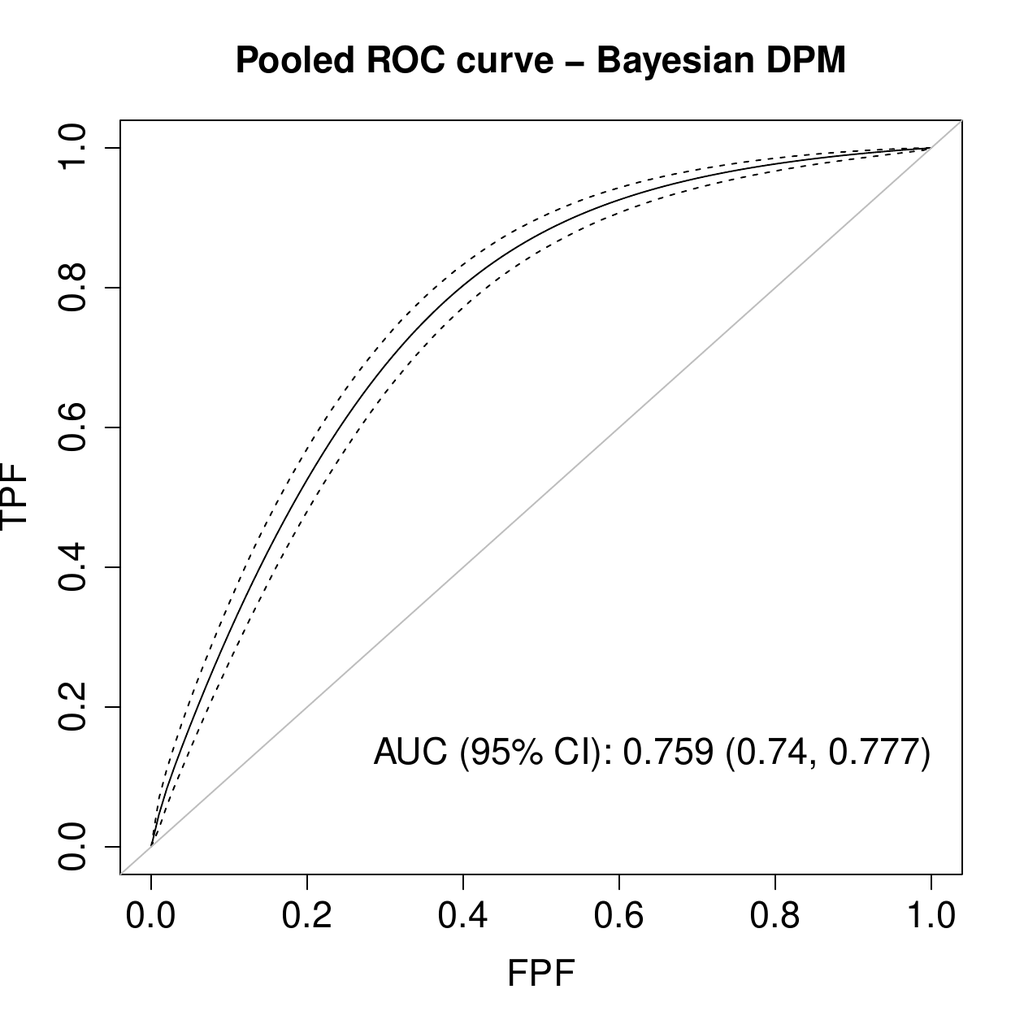

Figure 2: Graphical results as provided by the `plot.pooledROC` function for an object of class `pooledROC.dpm`. Posterior mean and 95% pointwise credible band for the pooled ROC curve and corresponding posterior mean and 95% credible interval for the AUC.

By means of `density = densitycontrol(compute = TRUE)` in the call to the function, the estimates of the PDFs of the BMI in both groups are to be returned. This information can be accessed through component `dens` in the object `pROC`$\_$`dpm` (i.e., `pROC`$\_$`dpm$dens`), which is a list with elements `h` and `d` associated with the nondiseased and diseased groups, respectively. Each of the two elements is itself another list of two components: (1) `grid`, a vector that contains the grid of test results at which the PDFs have been evaluated (estimated); and (2) `dens`, a matrix with the PDFs at each iteration of the MCMC procedure. We can use these results to plot, e.g., the posterior mean (and 95% pointwise credible bands) of the PDF of the BMI in the healthy and diseased populations (see Figure 3a obtained using the R package [*ggplot2*](https://CRAN.R-project.org/package=ggplot2) by (Wickham 2016)). As can be observed, the estimated densities obtained under the DPM method follow very closely the histograms of the data. Further, the estimated densities available in `dens` can be used, as advised by Gelman et al. (2013 553), to monitor convergence of the MCMC chains. The well-known label switching problem often leads to poor mixing of the chains of the component-specific parameters, but this may not impact convergence and mixing of the induced density/distribution of interest. For instance, Figure 4 shows the trace plots of the MCMC iterations (after burn-in) of the PDFs of the BMI in the two groups for different (and randomly selected) values of the BMI, and Figure 5 depicts the corresponding effective sample sizes and Geweke statistics (obtained using the R package [*coda*](https://CRAN.R-project.org/package=coda) by (Plummer et al. 2006)). Note that all plots give evidence of a good mixing and do not suggest a lack of convergence. For conciseness, the R code for reproducing Figures 3a, 4, and 5 is not provided here but in the replication code that accompanies the paper.

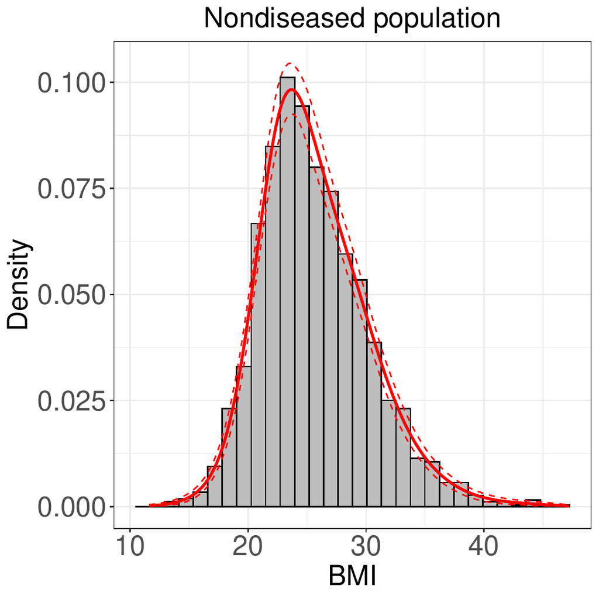

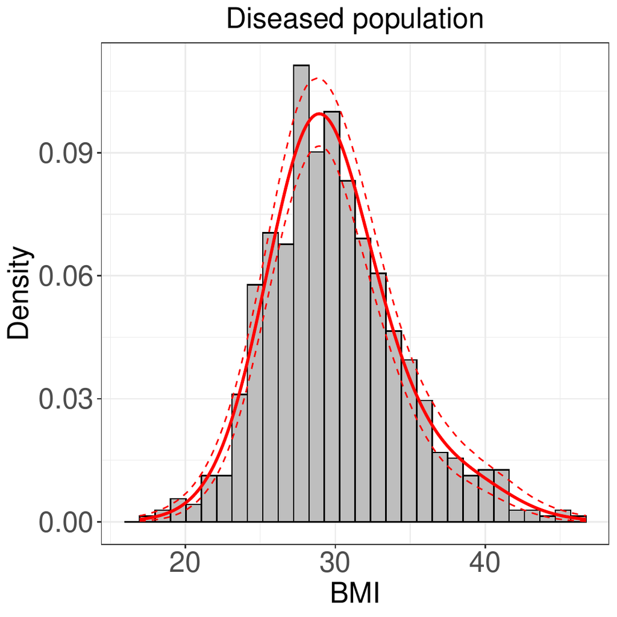

1. DPM model with 10 mixture components in each group

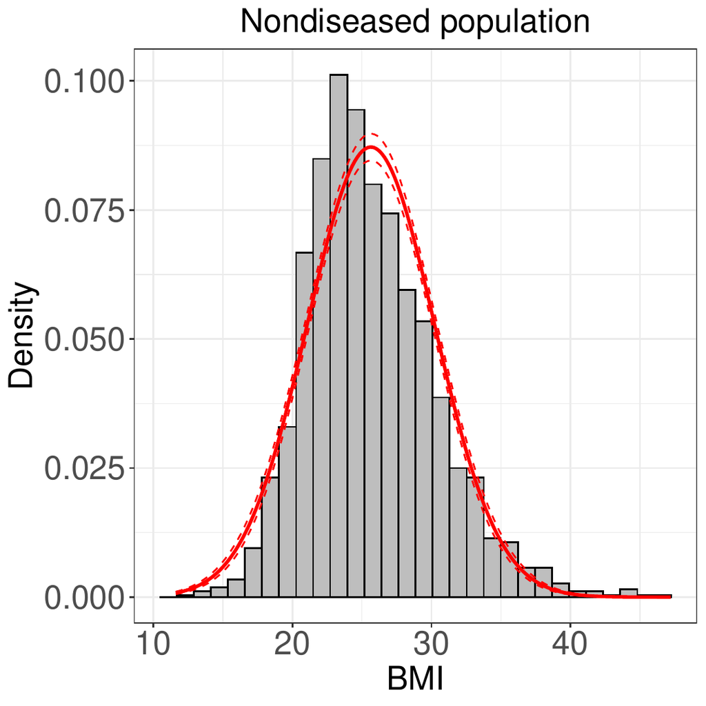

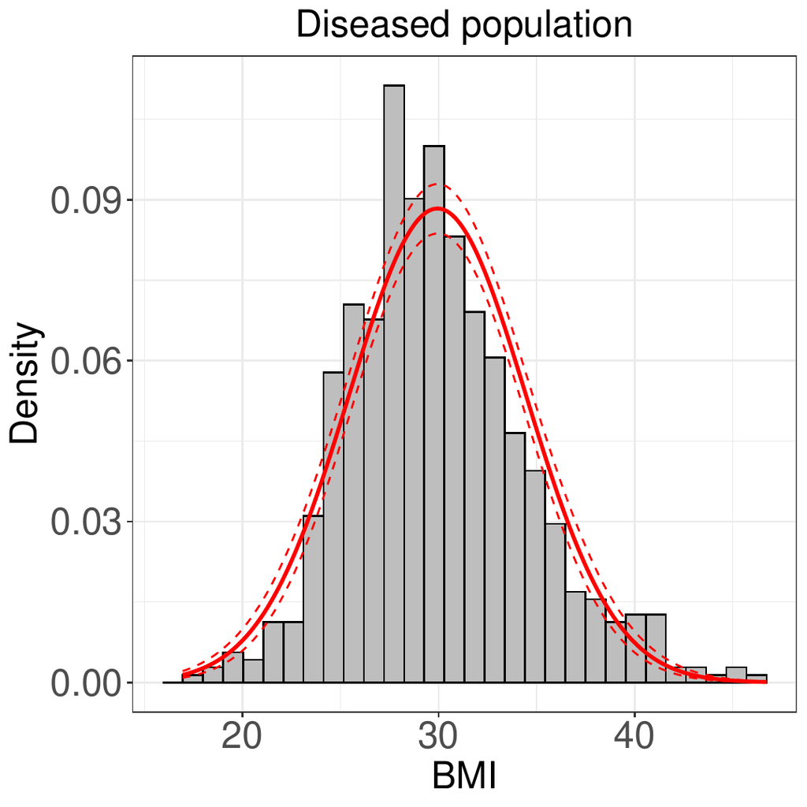

2. Normal model in each group

Figure 3: Histogram of the (observed) BMI and posterior mean jointly along with 95% pointwise credible bands (red lines) of the PDF of the BMI obtained using (a) a Dirichlet process mixture of normals model (object `pROC_dpm`); and (b) a normal model (object `pROC_normal`). Left: Nondiseased individuals (none or one CVD risk factor). Right: Diseased individuals (two or more CVD risk factors).

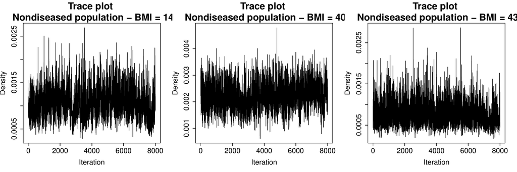

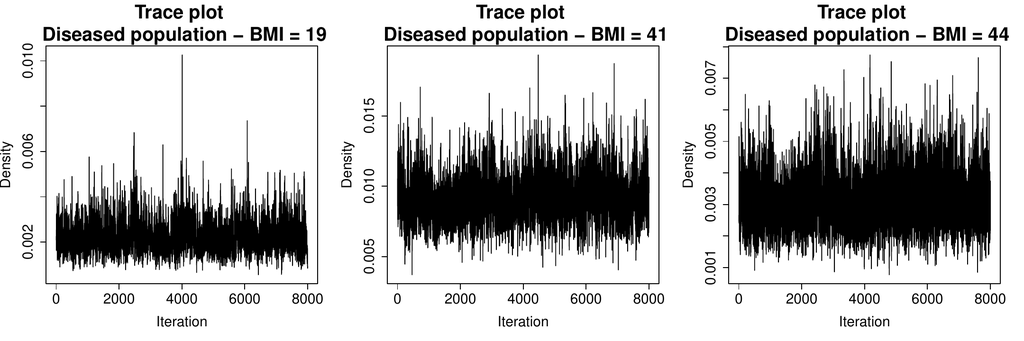

Figure 4: Trace plots of the MCMC draws (after burn-in) of the PDFs of the BMI based on the model `pROC_dpm`. Results are shown separately for the nondiseased and diseased populations and for different values of the BMI.

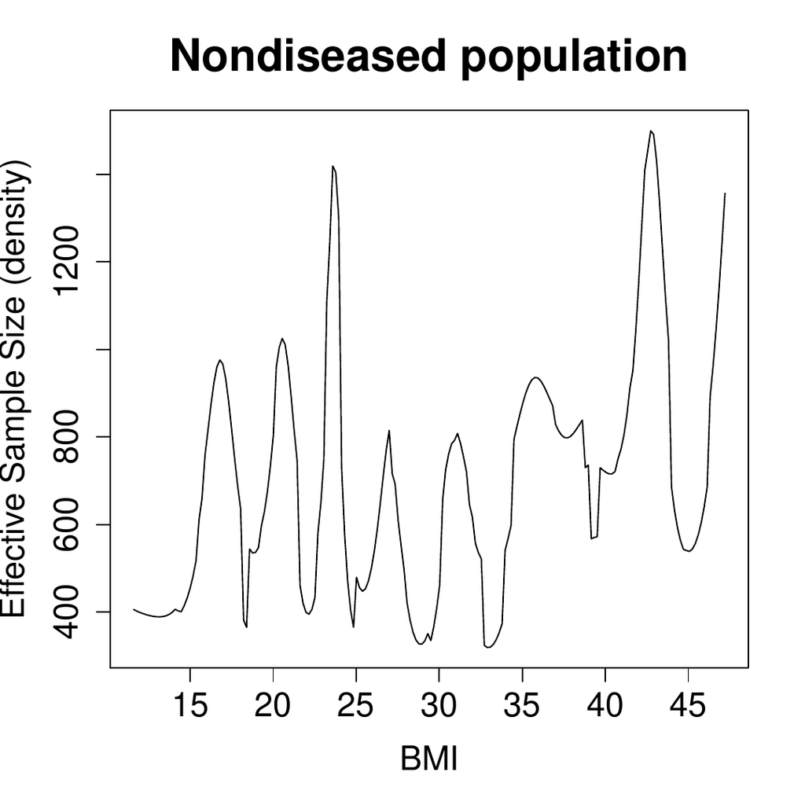

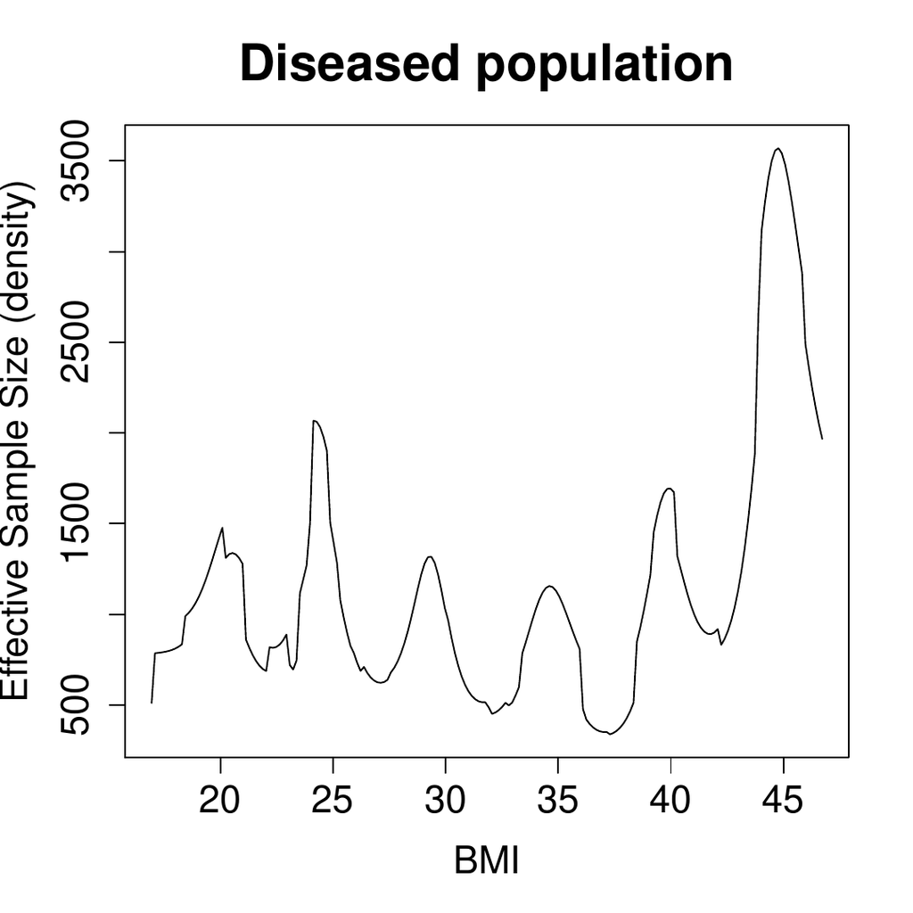

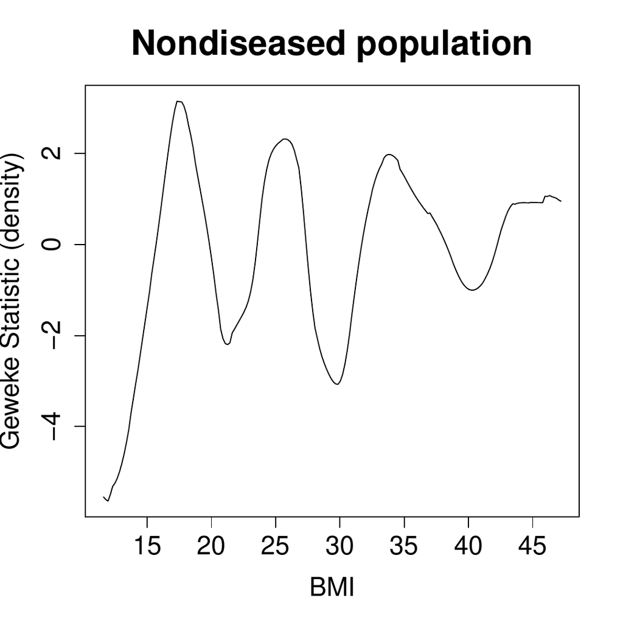

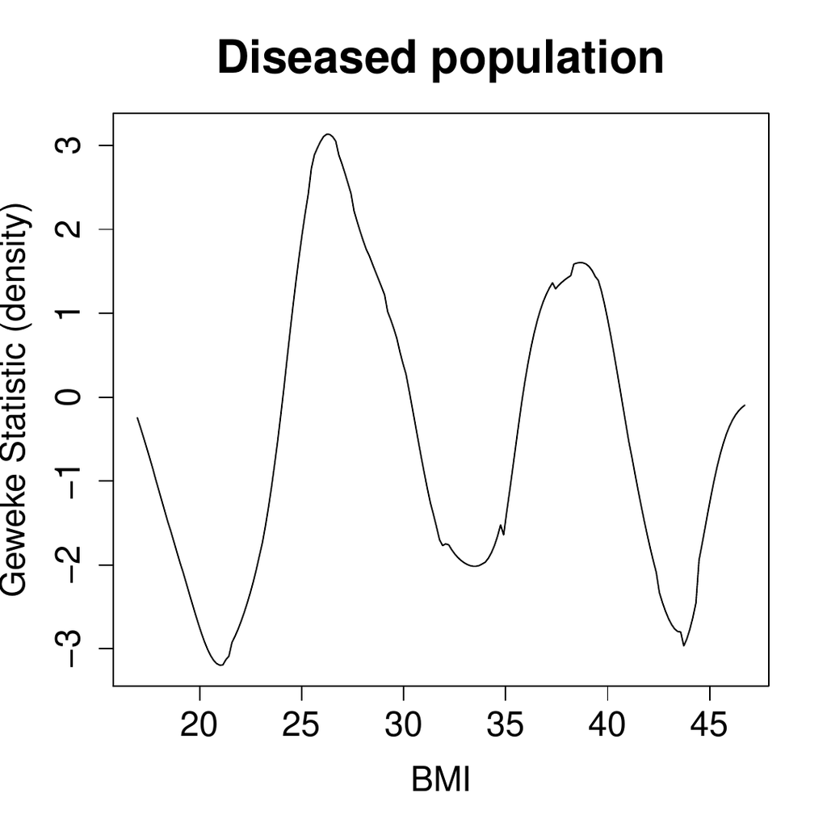

Figure 5: Effective sample size and Geweke statistic of the MCMC chains (after burn-in) and of the PDFs of the BMI based on model `pROC_dpm` in the nondiseased and diseased populations. In both cases, results are shown along BMI values.

It is worth noting that the function `pooledROC.dpm` also allows fitting a normal distribution in each group. This is just a particular case (for which $L_D=L_{\bar{D}}=1$) of the more general DPM model. In order to fit such model, one simply needs to set $L=1$ in the `prior.d` and `prior.h` arguments. The code follows.

```r
R> set.seed(123, "L'Ecuyer-CMRG") # for reproducibility
R> pROC_normal <- pooledROC.dpm(marker = "bmi", group = "cvd_idf", tag.h = 0,
+ data = endosyn, standardise = TRUE, p = seq(0, 1, l = 101), ci.level = 0.95,
+ compute.lpml = TRUE, compute.WAIC = TRUE, compute.DIC = TRUE,
+ pauc = pauccontrol(compute = TRUE, focus = "FPF", value = 0.1),
+ density = densitycontrol(compute = TRUE),
+ prior.h = priorcontrol.dpm(L = 1), prior.d = priorcontrol.dpm(L = 1),
+ mcmc = mcmccontrol(nsave = 8000, nburn = 2000, nskip = 1),
+ parallel = "snow", ncpus = 2)
```

For the sake of space, we omit from the summary the call to the function

```r
R> summary(pROC_normal)
```

```r
Call: [...]

Approach: Pooled ROC curve - Bayesian DPM
----------------------------------------------
Area under the pooled ROC curve: 0.748 (0.728, 0.768)*
Partial area under the pooled ROC curve (FPF = 0.1): 0.224 (0.194, 0.253)*
 * Credible level:  0.95

Model selection criteria:
                     Group H       Group D
WAIC               12639.952      4049.004
WAIC (Penalty)         2.431         2.267
LPML               -6319.976     -2024.502
DIC                12639.505      4048.714
DIC (Penalty)          1.986         1.987


Sample sizes:
                           Group H     Group D
Number of observations        2149         691
Number of missing data           0           0
```

The fit of the DPM and normal models in each group can be compared on the basis of the WAIC, DIC, and/or the LPML. Remember that for the LPML, the higher its value, the better the model fit, while for the WAIC and DIC, it is the other way around. By comparing these values, provided in the summary of each fitted model, we can conclude that the three criteria favor, in both the diseased and (especially in the) nondiseased groups, the more general DPM model. This is also corroborated by the plot of the fitted densities in each group shown in Figure 3b.